# **Исследование категории рода в норвежском языке**

Понимание факторов, влияющих на род существительных, имеет практическое значение:

•Изучение языка: Помогает учащимся запоминать и применять род.

•Обработка естественного языка: Улучшает машинный перевод и генерацию текста на норвежском.

•Корпусная лингвистика: Углубляет понимание структуры лексики и взаимосвязи между морфологией, семантикой и этимологией.

Мы исследуем влияние последних двух букв слова, значения и этимологии на определение рода норвежских существительных. Цель - выявить значимые факторы и оценить их вклад, чтобы лучше понять систему родов в норвежском языке.

Для этого мы проверим наличие статистически значимой связи между словом и его происхождением, длиной и семантическим типом, а также предложим модель для предсказания рода слова по этим признакам.

## Литературный обзор

@aabouzaid в своей [статье](https://github.com/aabouzaid/german-nouns-gender-analyzer) на гитхабе 10-тилетней давности описал построенную на частотности систему распознавания рода в немецком языке. Он подготовил датасет из немецких существительных и посчитал относительные частоты встретить слово на -Х каждого из родов.

В учебниках по норвежскому как иностранному приводятся списки аффиксов, характерные для каждого из родов, но в конце таких списков всегда есть помета о том, что опираться на них не стоят, потому что исключений из правил слишком много.

Методы машинного обучения тоже использовались для решения задачи автоматического определения рода в шугнанском языке [в этой статье](https://github.com/maxmerben/shughni-gender-detection/blob/main/Predicting%20the%20Gender%20Category%20for%20Shughni%20Nouns%20Using%20Machine%20Learning%20Methods.ipynb). Для построения модели для слов были определены семантические типы, последние буквы, последние гласные буквы, лексическое значение. Средняя ф1-мера по классу в этой работе составила порядка 70%. ## Импорты

```r
library(tidyverse)
```

```r
library(ggplot2)
library(RColorBrewer)
library(nnet)
library(BayesFactor)
library(caret)
```

## Датасет

Датасет, который мы подготовили, составлен на основе [англо-норвежского онлайн-словаря](https://enno.dict.cc/). Этот словарь, подобно Википедии, может пополнять каждый интернет-пользователь. Из-за этого в нем достаточно много слов, которые не ожидаешь встретить в словаре небольшого размера. Тем не менее сам ресурс размечен удобно для того, чтобы его можно было использовать для исследования.

```r
data <- read.csv('/Users/sergey/Downloads/substantivv3.csv', header = FALSE,
                col.names = c("substantiv", "slut", "kjønn", "stavelser", "etymologi", "typ"))

data <- data %>%
  mutate(
    stavelser = as.numeric(stavelser),
    kjønn = as.factor(kjønn),
    etymologi = as.factor(etymologi),
    typ = as.factor(typ)
  )
```

Датасет состоит из следующих переменных:

- substantiv - непосредственно имя существительное;
- slut - последние две буквы в нем;
- kjønn - род слова;
- stavelser - количество слогов в слове;
- etymologi - происхождение слова;
- typ - семантический тип. Несколько замечаний по заполнению датасета:
1. Род слова размечался в полуавтоматическом режиме с помощью XPath.
2. Концовки и количество слогов заполнялись при помощи регулярных выражений (дифтонги учтены).
3. Происхождение слова выписывалось в ручную по следующим принципам:
- если слово сложное, то учитывался только последний корень;
- слова, восходящие к праиндоевропейскому, древнескандинавскому, норвежскому помечались как слова скандинавского происхождения;
- слово, прошедшее через несколько этапов заимствований, но не ассимилировавшееся фонетически/графически/грамматически помечается как слово того языка, черты которого оно сохранило;
- топонимы в основном подписывались как слова неизвестного происхождения, чтобы не допустить слишком большое количество уникальных значений;
- таким же образом помечались слова, происхождение которых установить не удалось;
4. В случае полисемии семантический тип определялся по первому значению в словарной статье

```r
head(data)
```

```
##   substantiv slut kjønn stavelser    etymologi      typ
## 1 a-menneske   ke     n         4 Skandinavisk Menneske
## 2       Aage   ge     m         3 Skandinavisk Menneske
## 3      abbed   ed     m         2      Latinsk Religion
## 4     abbedi   di     n         3      Latinsk Religion
## 5  abbedisse   se   m/f         4      Latinsk Religion
## 6      abbor   or     m         2         Tysk      Dyr
```

Удалим из датасета NaN’ы.

```r
data <- data[str_trim(data$typ) != "",]
data <- na.omit(data)
summary(data)
```

```
##   substantiv            slut           kjønn        stavelser
##  Length:2629        Length:2629        m  :1562   Min.   : 0.000
##  Class :character   Class :character   m/f: 495   1st Qu.: 2.000
##  Mode  :character   Mode  :character   n  : 572   Median : 3.000
##                                                   Mean   : 3.163
##                                                   3rd Qu.: 4.000
##                                                   Max.   :11.000
##
##         etymologi           typ
##  Skandinavisk:1238   Abstrakt :884
##  Latinsk     : 392   Ting     :867
##  Gresk       : 309   Menneske :373
##  Fransk      : 171   Dyr      :157
##  Engelsk     : 165   Vitenskap:131
##  Tysk        : 163   Plant    : 69
##  (Other)     : 191   (Other)  :148
```

Род слова будем определять c учетом его последних букв, количества слогов, происхождения и семантической категории. Изучим очищенный от незаполненных строк датасет. ## Описательная статистика **Распределение слов по количеству слогов**

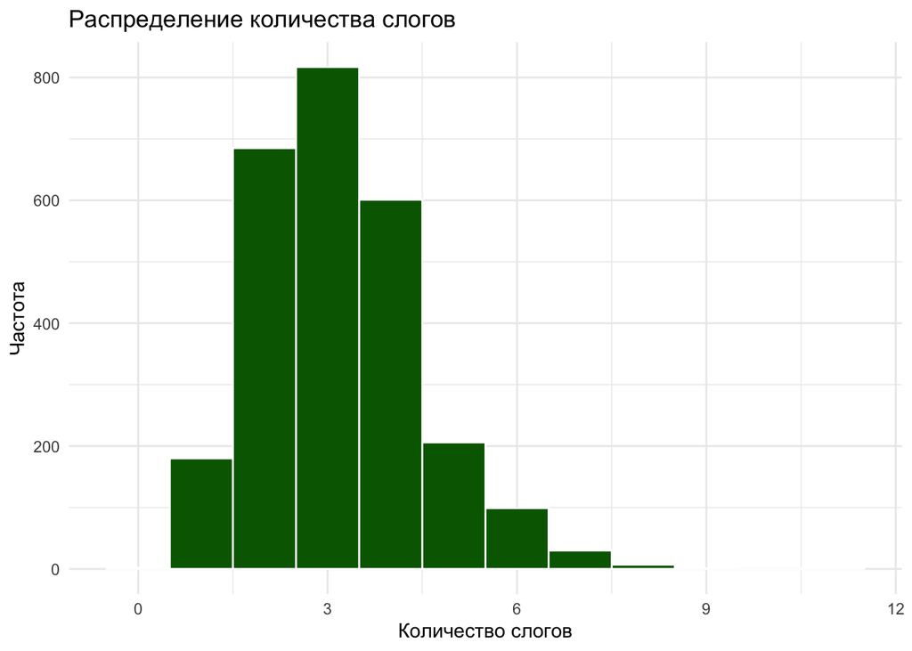

```r
ggplot(data, aes(x = stavelser)) +
  geom_histogram(binwidth = 1, fill = "darkgreen", color = "white") +
  labs(title = "Распределение количества слогов",
        x = "Количество слогов", y = "Частота") +
  theme_minimal()
```

**Распределение слов по категориям**

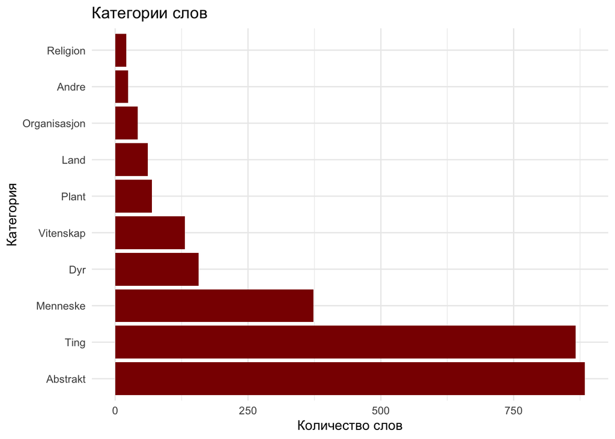

```r
ggplot(data, aes(x = fct_infreq(typ))) +
  geom_bar(fill = "darkred") +
  labs(title = "Категории слов",
    x = "Категория", y = "Количество слов") +
  coord_flip() +
  theme_minimal()
```

Лексика в словаре по большей части абстрактная. Вероятно, это связано с особенностью пополнения словаря.

**Распределение слов по родам**

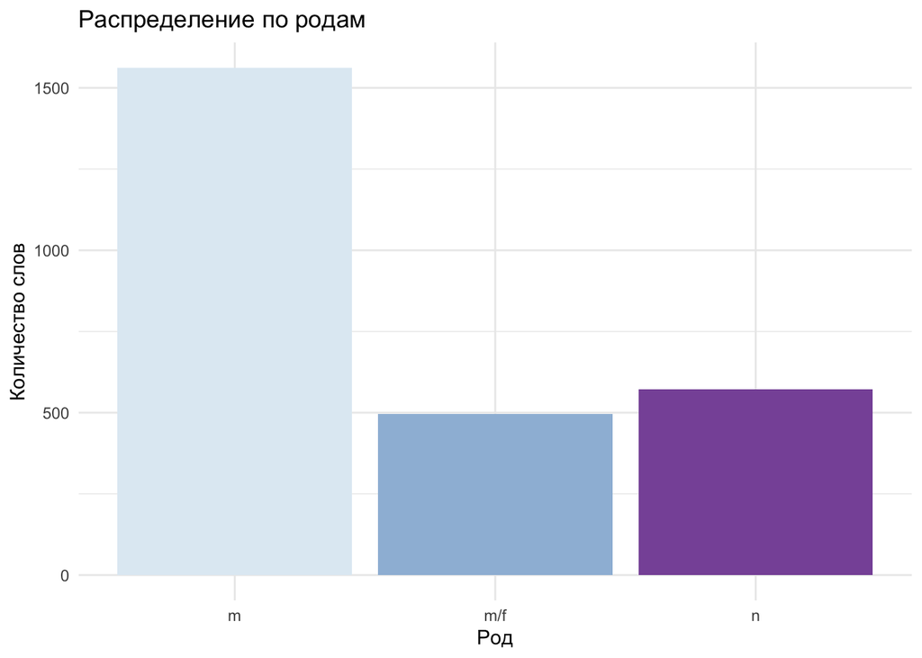

```r
ggplot(data, aes(x = kjønn, fill = kjønn)) +
  geom_bar() +
  scale_fill_brewer(palette = 3) +
  labs(title = "Распределение по родам",
       x = "Род", y = "Количество слов") +
  theme_minimal() +
  theme(legend.position = "none")
```

В целом распределение существительных в нашей выборке отражает реальную ситуацию: существительных мужского рода значительно больше. Так как наш датасет учитывает эту особенность генеральной совокупности, мы не будем пользоваться методами over-/undersampling’а.

**Соотношение категорий по происхождению**

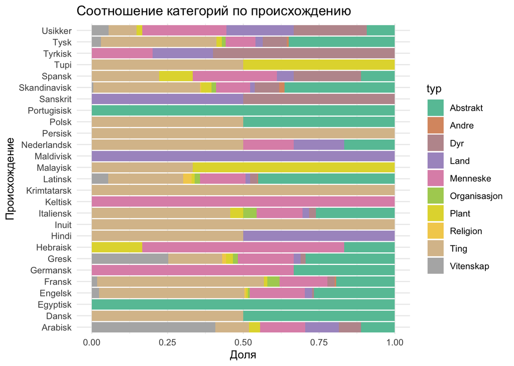

```r
ggplot(data, aes(x = etymologi, fill = typ)) +
  geom_bar(position = "fill") +
  scale_fill_manual(values = colorRampPalette(brewer.pal(8, "Set2"))(length(unique(data$typ)))) +
  labs(title = "Соотношение категорий по происхождению",
       x = "Происхождение", y = "Доля") +
  coord_flip() +
  theme_minimal()
```

Этот график демонстрирует, какие сферы жизни затрагивают заимствования из разных языков. Например, на графике заметно, что бóльшую часть заимствований из латинского языка составляют абстрактные сущности. В целом это суждение звучит правдоподобно, потому что латинский язык - один из основных языков науки, где в основном используются абстрактные имена. NB: для редких языков (например, крымско-татарского) шкала одного цвета означает не заимствования только из одной сферы, а небольшое количество этих заимствований, из-за которого линии получаются немногоцветными.

**Распределение количества слов по категориям**

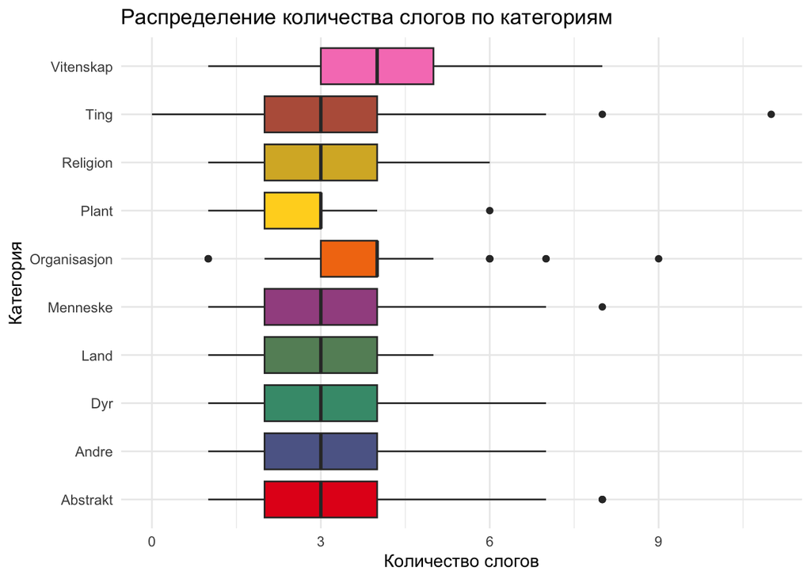

```r
ggplot(data, aes(x = typ, y = stavelser, fill = typ)) +
  geom_boxplot() +
  scale_fill_manual(values = colorRampPalette(brewer.pal(8, "Set1"))(length(unique(data$typ)))) +
  labs(title = "Распределение количества слогов по категориям",
       x = "Категория", y = "Количество слогов") +
  coord_flip() +
  theme_minimal() +
  theme(legend.position = "none")
```

На графике представлено распределение количества слогов по различным категориям. По горизонтальной оси отложено количество слогов, а по вертикальной - категории.

Видно, что типичная длина слов в разных категориях неодинакова. Например, названия животных обычно короче, чем названия терминов (Vitenskap)

## Предобработка

Сократим количество уникальных значений в категории “слоги”. Объединим все длинные (4+ слогов) слова в одну категорию – 4+.

```r
data$stavelser_cat <- cut(data$stavelser,
                         breaks = c(0, 1, 2, 3, Inf),
                         labels = c("1", "2", "3", "4+"))
```

В датасете у слов несколько сотен уникальных концовок. Сократим это количество, объединив все значения по фонетическому принципу.

```r
vowels <- c('a', 'e', 'i', 'o', 'u', 'y', 'æ', 'ø', 'å', 'é', 'è', 'ê', 'ë')
consonants <- c('b', 'c', 'd', 'f', 'g', 'h', 'j', 'k', 'l', 'm', 'n',
  'p', 'q', 'r', 's', 't', 'v', 'w', 'x', 'z')

replace_VC <- function(text) {
  text <- tolower(text)
  vowels <- c("a", "e", "i", "o", "u")
  consonants <- letters[! letters %in% vowels]
  result <- gsub(paste(vowels, collapse = "|"), "V", text)
  result <- gsub(paste(consonants, collapse = "|"), "C", result)
  return(result)
}

data$slut <- sapply(data$slut, replace_VC)
```

## Хи-квадраты

Наша целевая переменная категориальна, поэтому, чтобы определить, с какими признаками она имеет статистически значимую связь, нам необходимо провести несколько независимых проверок статистических гипотез. Для установления статистически значимой связи подойдет тест Хи-квадрат. **Взаимосвязь рода и количества слогов** Н0: взаимосвязь отсутствует

Н1: взаимосвязь есть

```r
chi_gender_syllables <- chisq.test(table(data$kjønn, data$stavelser_cat))
print(chi_gender_syllables)
```

```
##
##  Pearson's Chi-squared test
##
## data:  table(data$kjønn, data$stavelser_cat)
## X-squared = 24.002, df = 6, p-value = 0.0005219
```

p.value < 0.05 => отвергаем Н0 на уровне значимости 0.05

Длина слова влияет на его род.

**Взаимосвязь рода и семантического типа** Н0: взаимосвязь отсутствует

Н1: взаимосвязь есть

```r
fisher.test(table(data$kjønn, data$typ), simulate.p.value = TRUE)
```

```
##
##  Fisher's Exact Test for Count Data with simulated p-value (based on
##  2000 replicates)
##
## data:  table(data$kjønn, data$typ)
## p-value = 0.0004998
## alternative hypothesis: two.sided
```

p.value < 0.05 => отвергаем Н0 на уровне значимости 0.05

Семантическая категория влияет на род.

**Взаимосвязь рода и происхождения** Н0: взаимосвязь отсутствует

Н1: взаимосвязь есть

```r
fisher.test(table(data$kjønn, data$etymologi), simulate.p.value = TRUE)
```

```
##
##  Fisher's Exact Test for Count Data with simulated p-value (based on
##  2000 replicates)
##
## data:  table(data$kjønn, data$etymologi)
## p-value = 0.0004998
## alternative hypothesis: two.sided
```

p.value < 0.05 => отвергаем Н0 на уровне значимости 0.05

Происхождение слова влияет на род.

**Взаимосвязь рода и последних звуков (CV)** Н0: взаимосвязь отсутствует

Н1: взаимосвязь есть

```r
chi_gender_ending <- chisq.test(table(data$kjønn, data$slut))
cat("\nХи-квадрат тест: род vs концовка\n")
```

```
##
## Хи-квадрат тест: род vs концовка
```

```r
print(chi_gender_ending)
```

```
##
##  Pearson's Chi-squared test
##
## data:  table(data$kjønn, data$slut)
## X-squared = 212.48, df = 20, p-value < 2.2e-16
```

p.value < 0.05 => отвергаем Н0 на уровне значимости 0.05

Стоит отметить, что аффиксация часто предполагает определенный род у норвежских существительных, а наш результат вызван тем, что мы слишком генерализовали категорию.

Так как мы выявили о том, что выделенные признаки оказывают влияние на род, имеет смысл посмотреть, как именно связаны род и длина, происхождение, тип. ## Зависимости

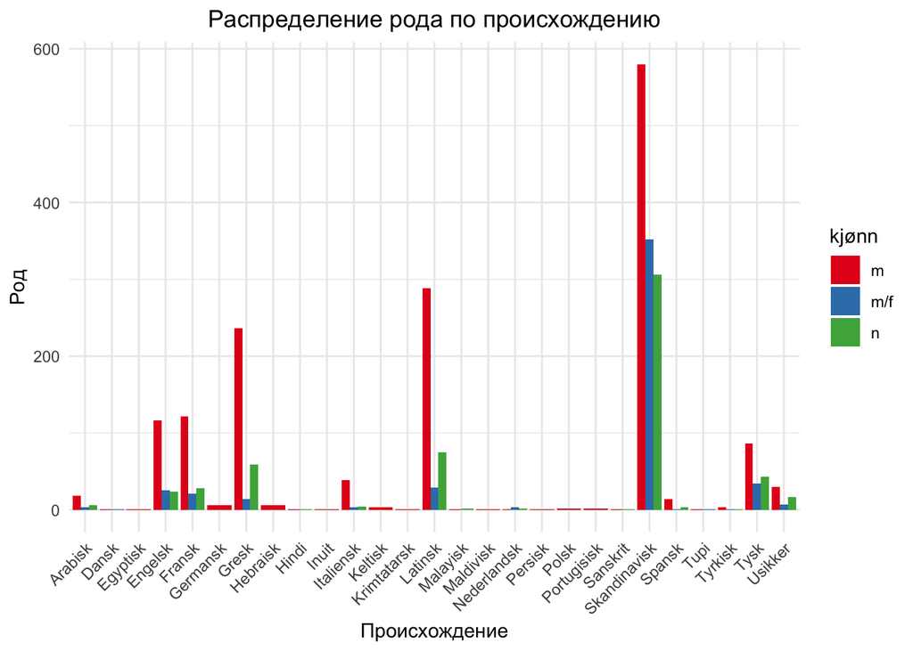

```r
ggplot(data, aes(x = etymologi, fill = kjønn)) +
  geom_bar(position = "dodge") +
  labs(title = "Распределение рода по происхождению", x = "Происхождение", y = "Род") +
  theme_minimal() +
  theme(plot.title = element_text(hjust = 0.5)) +
  scale_fill_brewer(palette = "Set1") +
  theme(axis.text.x = element_text(angle = 45, hjust = 1))
```

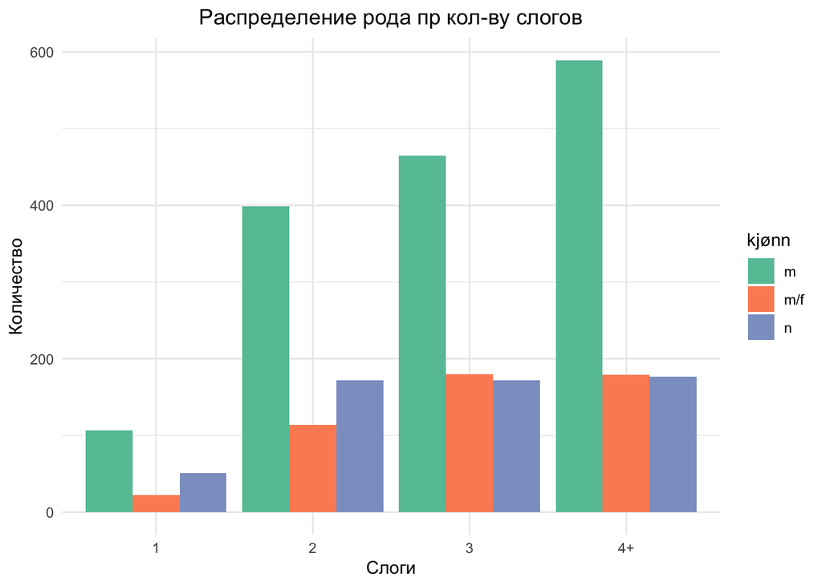

```r
ggplot(data, aes(x = factor(stavelser_cat), fill = kjønn)) +
  geom_bar(position = "dodge") +
  scale_x_discrete(limits = c("1", "2", "3", "4+")) +
  labs(title = "Распределение рода пр кол-ву слогов", x = "Слоги", y = "Количество") +
  theme_minimal() +
  scale_fill_brewer(palette = "Set2") +
  theme(plot.title = element_text(hjust = 0.5))
```

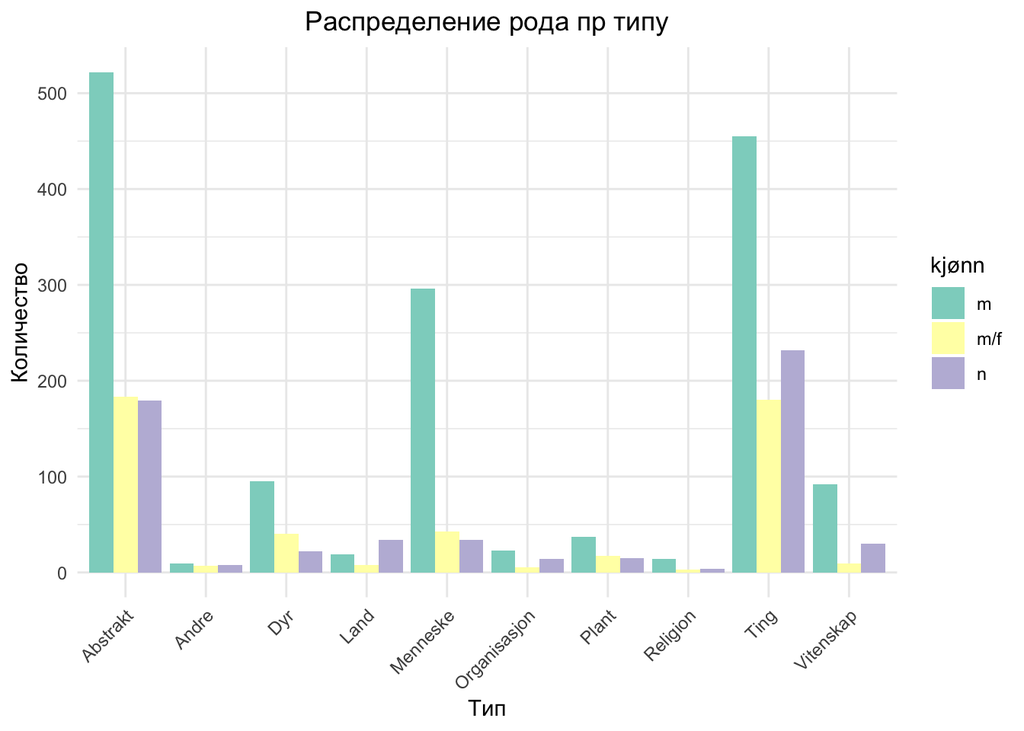

```r
ggplot(data, aes(x = typ, fill = kjønn)) +
  geom_bar(position = "dodge") +
  labs(title = "Распределение рода пр типу", x = "Тип", y = "Количество") +
  theme_minimal() +
  theme(plot.title = element_text(hjust = 0.5)) +
  scale_fill_brewer(palette = "Set3") +
  theme(axis.text.x = element_text(angle = 45, hjust = 1))
```

## Байесовская статистика

Оценим, насколько сильна установленная выше связь с помощью байесовской статистики.

```r
contingency_table <- table(data$kjønn, data$etymologi)

bf_etym <- contingencyTableBF(contingency_table, sampleType = "indepMulti", fixedMargin = "rows")

bf_etym
```

```
## Bayes factor analysis
## --------------
## [1] Non-indep. (a=1) : 2.418611e-11 ±0%
##
## Against denominator:
##   Null, independence, a = 1
## ---
## Bayes factor type: BFcontingencyTable, independent multinomial
```

```r
contingency_table_typ <- table(data$kjønn, data$typ)
bf_typ <- contingencyTableBF(contingency_table_typ, sampleType = "indepMulti", fixedMargin = "rows")
bf_typ
```

```
## Bayes factor analysis
## --------------
## [1] Non-indep. (a=1) : 1.448063e+12 ±0%
##
## Against denominator:
##   Null, independence, a = 1
## ---
## Bayes factor type: BFcontingencyTable, independent multinomial
```

```r
contingency_table_slut <- table(data$kjønn, data$slut)
bf_slut <- contingencyTableBF(contingency_table_slut, sampleType = "indepMulti", fixedMargin = "rows")
bf_slut
```

```
## Bayes factor analysis
## --------------
## [1] Non-indep. (a=1) : 1.646669e+21 ±0%
##
## Against denominator:
##   Null, independence, a = 1
## ---
## Bayes factor type: BFcontingencyTable, independent multinomial
```

## Логистическая регрессия

Построим модель, предсказывающую род существительного

```r
model_data <- data %>%
  select(kjønn, typ, etymologi, stavelser_cat, slut) %>%
  na.omit() %>%
  mutate(kjønn = kjønn,
         typ = typ,
         etymologi = etymologi,
         slut = slut)
         #substantiv = substantiv

train_index <- sample(1:nrow(model_data), 0.7 * nrow(model_data))
train_data <- model_data[train_index, ]
test_data <- model_data[-train_index, ]
```

```r
model <- multinom(kjønn ~ typ + etymologi + stavelser_cat + slut, data = train_data)
predictions <- predict(model, newdata = test_data)
```

```r
conf_matrix <- confusionMatrix(predictions, test_data$kjønn)
conf_matrix
```

```
## Confusion Matrix and Statistics
##
##           Reference
## Prediction   m m/f   n
##        m   414  96 129
##        m/f  45  54  21
##        n    12   3  15
##
## Overall Statistics
##
##                Accuracy : 0.6122
##                  95% CI : (0.5772, 0.6463)
##     No Information Rate : 0.597
##     P-Value [Acc > NIR] : 0.2022
##
##                   Kappa : 0.1905
##
##  Mcnemar's Test P-Value : <2e-16
##
## Statistics by Class:
##
##                      Class: m Class: m/f Class: n
## Sensitivity            0.8790    0.35294  0.09091
## Specificity            0.2925    0.89623  0.97596
## Pos Pred Value         0.6479    0.45000  0.50000
## Neg Pred Value         0.6200    0.85202  0.80237
## Prevalence             0.5970    0.19392  0.20913
## Detection Rate         0.5247    0.06844  0.01901
## Detection Prevalence   0.8099    0.15209  0.03802
## Balanced Accuracy      0.5857    0.62458  0.53344
```

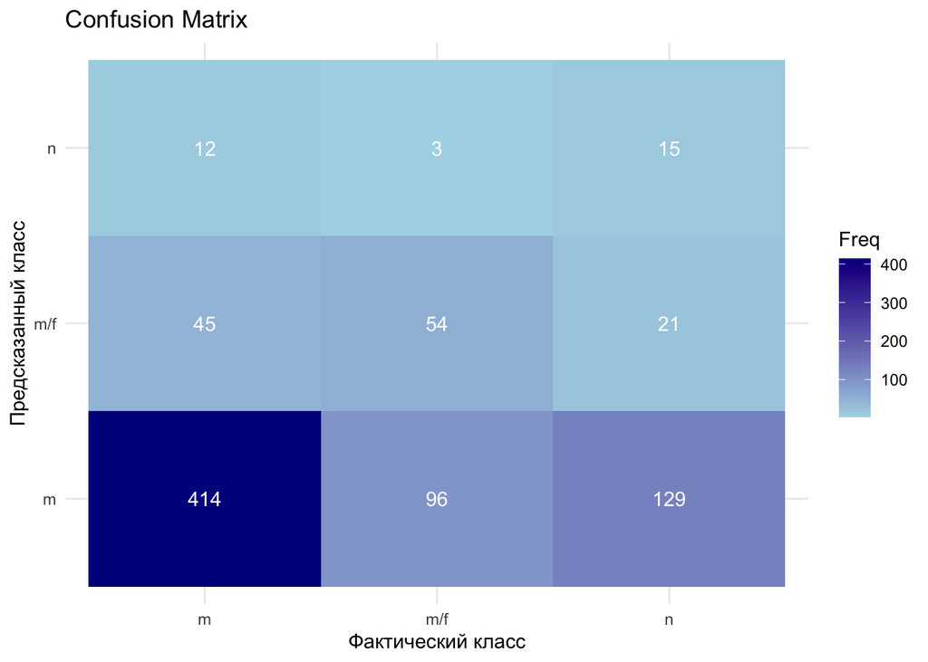

```r
ggplot(as.data.frame(conf_matrix$table),
       aes(x = Reference, y = Prediction, fill = Freq)) +
  geom_tile() +
  geom_text(aes(label = Freq), color = "white") +
  scale_fill_gradient(low = "lightblue", high = "darkblue") +
  labs(title = "Confusion Matrix",
       x = "Фактический класс",
       y = "Предсказанный класс") +
  theme_minimal()
```

```r
sum(conf_matrix$byClass[,"F1"] * as.numeric(table(test_data$kjønn))) / nrow(test_data)
```

```
## [1] 0.5541858
```

Существительные женского рода зачастую не выделяют в отдельный класс (например, в бергенском диалекте). В таком случае все существительные приобретают мужской род. Проверим, как изменится качество, если объединить существительные мужского и женского рода в один класс.

```r
test_data$kjonn_combined <- ifelse(test_data$kjønn %in% c("m", "m/f"), "m+", "n")
predictions_combined <- ifelse(predictions %in% c("m", "m/f"), "m+", "n")

  test_data$kjonn_combined <- factor(test_data$kjonn_combined, levels = c("m+", "n"))
predictions_combined <- factor(predictions_combined, levels = c("m+", "n"))

conf_matrix <- confusionMatrix(predictions_combined, test_data$kjonn_combined)
conf_matrix
```

```
## Confusion Matrix and Statistics
##
##           Reference
## Prediction  m+   n
##         m+ 609 150
##         n   15  15
##
##                Accuracy : 0.7909
##                  95% CI : (0.7608, 0.8188)
##     No Information Rate : 0.7909
##     P-Value [Acc > NIR] : 0.5208
##
##                   Kappa : 0.0957
##
##  Mcnemar's Test P-Value : <2e-16
##
##             Sensitivity : 0.97596
##             Specificity : 0.09091
##          Pos Pred Value : 0.80237
##          Neg Pred Value : 0.50000
##              Prevalence : 0.79087
##          Detection Rate : 0.77186
##    Detection Prevalence : 0.96198
##       Balanced Accuracy : 0.53344
##
##        'Positive' Class : m+
##
```

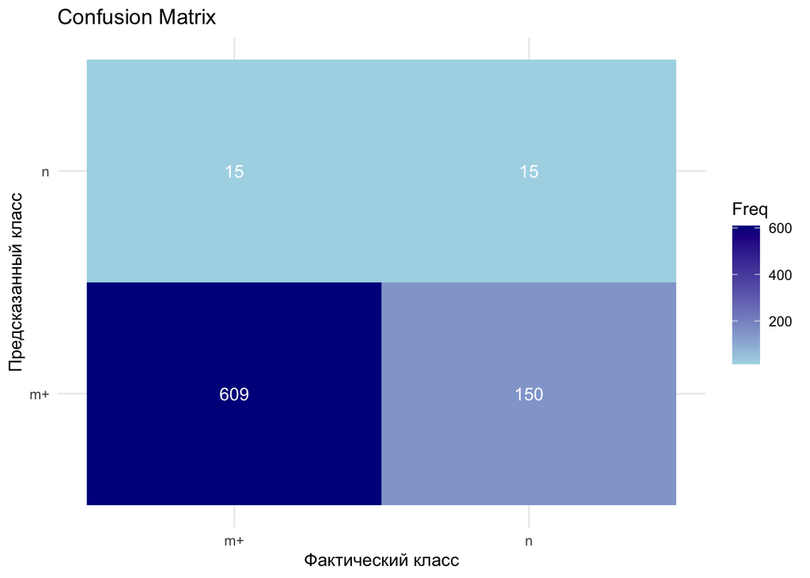

```r
ggplot(as.data.frame(conf_matrix$table),
       aes(x = Reference, y = Prediction, fill = Freq)) +
  geom_tile() +
  geom_text(aes(label = Freq), color = "white") +
  scale_fill_gradient(low = "lightblue", high = "darkblue") +
  labs(title = "Confusion Matrix",
       x = "Фактический класс",
       y = "Предсказанный класс") +
  theme_minimal()
```

## Выводы

На уровне значимости 5% полученные результаты свидетельствуют о том, что грамматический род в норвежском языке зависит от количества слогов, происхождения слова, его окончания и семантического типа. Тем не менее полученных данных оказалось недостаточно, чтобы обучить модель, которая бы хорошо справлялась с существительными немужского рода.

## Пространство для улучшения

- закончить датасет
- пересмотреть набор признаков